# Faraway

Harry Woo

2020-5-12

## Chapter 2 Estimation

## Problem 1

*The dataset teengamb concerns a study of teenage gambling in Britain. Fit a regression model with the expenditure on gambling as the response and the sex, status, income and verbal score as predictors. Present the output.*

```r
data(teengamb)
head(teengamb)
```

```
##   sex status income verbal gamble
## 1   1     51   2.00      8    0.0
## 2   1     28   2.50      8    0.0
## 3   1     37   2.00      6    0.0
## 4   1     28   7.00      4    7.3
## 5   1     65   2.00      8   19.6
## 6   1     61   3.47      6    0.1
```

```r
tg_lm <-  lm(gamble ~ sex + status + income + verbal, data = teengamb)
tg_lms <- summary(tg_lm)
print(tg_lms)
```

```
##
## Call:
## lm(formula = gamble ~ sex + status + income + verbal, data = teengamb)
##
## Residuals:
##     Min      1Q  Median      3Q     Max
## -51.082 -11.320  -1.451   9.452  94.252
##
## Coefficients:
##              Estimate Std. Error t value Pr(>|t|)
## (Intercept)  22.55565   17.19680   1.312   0.1968
## sex         -22.11833    8.21111  -2.694   0.0101 *
## status        0.05223    0.28111   0.186   0.8535
## income        4.96198    1.02539   4.839 1.79e-05 ***
## verbal       -2.95949    2.17215  -1.362   0.1803
## ---
## Signif. codes:  0 '***' 0.001 '**' 0.01 '*' 0.05 '.' 0.1 ' ' 1
##
## Residual standard error: 22.69 on 42 degrees of freedom
## Multiple R-squared:  0.5267, Adjusted R-squared:  0.4816
## F-statistic: 11.69 on 4 and 42 DF,  p-value: 1.815e-06
```

### (a) What percentage of variation in the response is explained by these predictors?

전체 제곱합(SST)에서 회귀 제곱합(SSR)이 설명하는 비중, 즉 모형의 설명력은 결정 계수 R<sup>2</sup> 이다. 위 Summary 에서와 같이 동 모형의 결정계수 **Multiple R-squared = 0.5267** 이다.

```r
var_ex <- data.frame(Var_explained = tg_lms$r.squared)
var_ex %>% gt() %>%
  fmt_percent(columns = vars(Var_explained),
              decimals = 2)
```

| Var_explained |
| --- |
| 52.67% |

### (b) Which observation has the largest (positive) residual? Give the case number.

회귀모형의 `residuals` 를 데이터프레임으로 변환하여 잔차값 기준으로 내림차순 정렬을 시행해 largest residual의 case number를 추출한 결과, **해당 case number는 24** 이다.

```r
res <- data.frame(case_no = c(1:47), residual = tg_lm$residuals)
res %>%
  arrange(desc(residual)) %>%
  slice(1) %>%
  gt()
```

| case_no | residual |
| --- | --- |
| 24 | 94.25222 |

### (c) Compute the mean and median of the residuals.

.

```r
res %>%
  summarise(mean = mean(residual), median = median(residual)) %>%
  gt()
```

| mean | median |
| --- | --- |
| -3.065293e-17 | -1.451392 |

### (d) Compute the correlation of the residuals with the fitted values.

.

```r
data.frame(correlation = cor(tg_lm$residuals, tg_lm$fitted.values)) %>%
  gt()
```

| correlation |
| --- |
| -1.070659e-16 |

### (e) Compute the correlation of the residuals with the income.

.

```r
data.frame(correlation = cor(teengamb$income, tg_lm$fitted.values)) %>%
  gt()
```

[output not shown]

### (f) For all other predictors held constant, what would be the difference in predicted expenditure on gambling for a male compared to a female?

.

```r
data.frame(Gender_coef = tg_lm$coefficients["sex"]) %>%
  gt()
```

| Gender_coef |
| --- |
| -22.11833 |

## Chapter 3 Interference

## Problem 1

*For the prostate data, fit a model with lpsa as the response and the other variables as predictors.*

```r
data(prostate)
head(prostate)
```

```
##       lcavol lweight age      lbph svi      lcp gleason pgg45     lpsa
## 1 -0.5798185  2.7695  50 -1.386294   0 -1.38629       6     0 -0.43078
## 2 -0.9942523  3.3196  58 -1.386294   0 -1.38629       6     0 -0.16252
## 3 -0.5108256  2.6912  74 -1.386294   0 -1.38629       7    20 -0.16252
## 4 -1.2039728  3.2828  58 -1.386294   0 -1.38629       6     0 -0.16252
## 5  0.7514161  3.4324  62 -1.386294   0 -1.38629       6     0  0.37156
## 6 -1.0498221  3.2288  50 -1.386294   0 -1.38629       6     0  0.76547
```

```r
ps_lm <- lm(lpsa ~ lcavol + lweight + age + lbph + svi + lcp + gleason + pgg45, data = prostate)
ps_lms <- summary(ps_lm)
ps_lms
```

```
##
## Call:
## lm(formula = lpsa ~ lcavol + lweight + age + lbph + svi + lcp +
##     gleason + pgg45, data = prostate)
##
## Residuals:
##     Min      1Q  Median      3Q     Max
## -1.7331 -0.3713 -0.0170  0.4141  1.6381
##
## Coefficients:
##              Estimate Std. Error t value Pr(>|t|)
## (Intercept)  0.669337   1.296387   0.516  0.60693
## lcavol       0.587022   0.087920   6.677 2.11e-09 ***
## lweight      0.454467   0.170012   2.673  0.00896 **
## age         -0.019637   0.011173  -1.758  0.08229 .
## lbph         0.107054   0.058449   1.832  0.07040 .
## svi          0.766157   0.244309   3.136  0.00233 **
## lcp         -0.105474   0.091013  -1.159  0.24964
## gleason      0.045142   0.157465   0.287  0.77503
## pgg45        0.004525   0.004421   1.024  0.30886
## ---
## Signif. codes:  0 '***' 0.001 '**' 0.01 '*' 0.05 '.' 0.1 ' ' 1
##
## Residual standard error: 0.7084 on 88 degrees of freedom
## Multiple R-squared:  0.6548, Adjusted R-squared:  0.6234
## F-statistic: 20.86 on 8 and 88 DF,  p-value: < 2.2e-16
```

### (a) Compute 90 and 95% CIs for the parameter associated with age. Using just these intervals, what could we have deduced about the p-value for age in the regression summary?

/

```r
confint(ps_lm, parm = "age", level = 0.90)
```

```
##            5 %         95 %
## age -0.0382102 -0.001064151
```

```r
confint(ps_lm, parm = "age", level = 0.95)
```

```
##           2.5 %      97.5 %
## age -0.04184062 0.002566267
```

```r
names(ps_lms)
```

```
##  [1] "call"          "terms"         "residuals"     "coefficients"
##  [5] "aliased"       "sigma"         "df"            "r.squared"
##  [9] "adj.r.squared" "fstatistic"    "cov.unscaled"
```

```r
ps_lms$coefficients["age", "Pr(>|t|)"]
```

```
## [1] 0.08229321
```

### (b) Compute and display a 95% joint confidence region for the parameters associated with age and lbph. Plot the origin on this display. The location of the origin on the display tells us the outcome of a certain hypothesis test. State that test and its outcome.

/

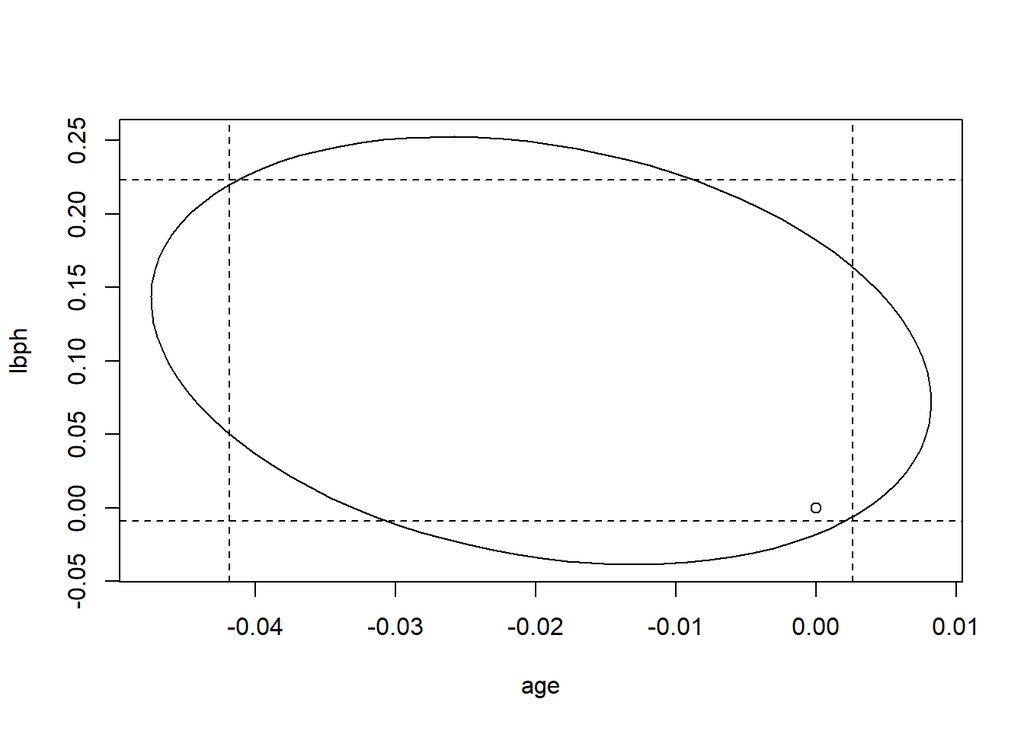

```r
library(ellipse)
plot(ellipse(ps_lm, c("age", "lbph")), type = "l")
points(0, 0, pch = 1)
abline(v = confint(ps_lm)['age', ], lty = 2)
abline(h = confint(ps_lm)['lbph', ], lty = 2)
```

### Predict the lpsa for this patient along with an appropriate 95% CI.

/

```r
new_patient <- data.frame(
  "lcavol" = 1.44692,
  "lweight" = 3.62301,
  "age" = 65.00000,
  "lbph" = 0.30010,
  "svi" = 0.00000,
  "lcp" = -0.79851,
  "gleason" = 7.00000,
  "pgg45" = 15.00000
)

new_patient
```

```
##    lcavol lweight age   lbph svi      lcp gleason pgg45
## 1 1.44692 3.62301  65 0.3001   0 -0.79851       7    15
```

```r
predict(ps_lm, newdata = new_patient, interval = "prediction")
```

```
##        fit       lwr      upr
## 1 2.389053 0.9646584 3.813447
```

### (d) Repeat the last question for a patient with the same values except that he or she is age 20. Explain why the CI is wider.

/

```r
new_patient2 <- new_patient
new_patient2[3] = 20
rbind(new_patient, new_patient2)
```

```
##    lcavol lweight age   lbph svi      lcp gleason pgg45
## 1 1.44692 3.62301  65 0.3001   0 -0.79851       7    15
## 2 1.44692 3.62301  20 0.3001   0 -0.79851       7    15
```

```r
predict(ps_lm, newdata = new_patient2, interval = "prediction")
```

```
##        fit      lwr      upr
## 1 3.272726 1.538744 5.006707
```

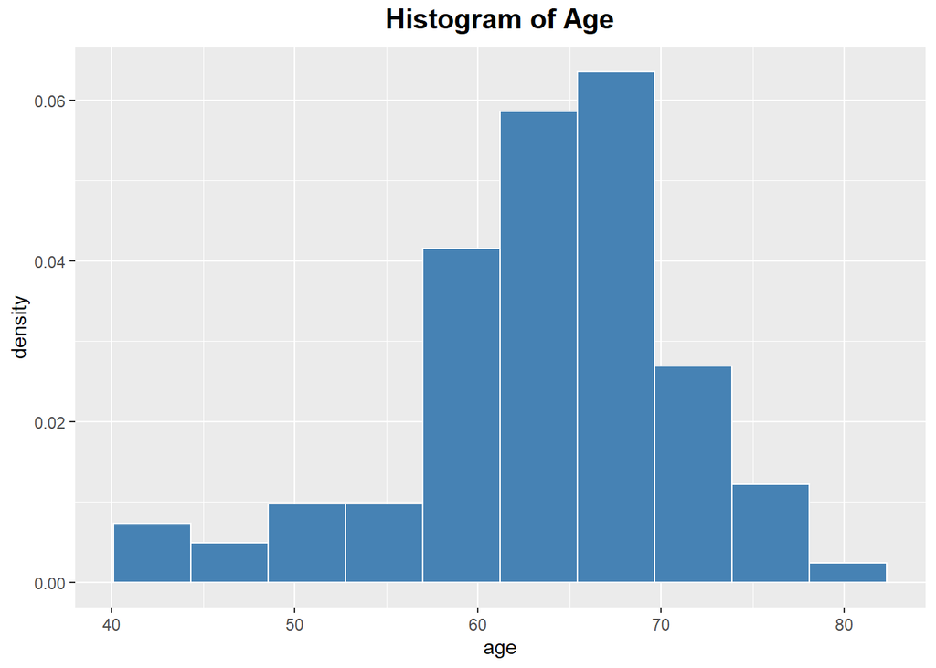

```r
ggplot(data = prostate, aes(x = age, y = ..density..)) +
  geom_histogram(bins = 10, fill = "steelblue", colour = "white") +
  ggtitle(label = "Histogram of Age") +
  theme(plot.title = element_text(size = 15, hjust = 0.5, vjust = 1.5, face = "bold"))
```

### (e) In the text, we made a permutation test corresponding to the F-test for the significance of all the predictors. Execute the permutation test corresponding to the t-test for age in this model. (Hint: {summary (g) $coef [4,3] gets you the t-statistic you need if the model is called g.)

/

```r
t_value <- summary(ps_lm) %>%
  coef() %>%
  .["age", "t value"]

permute_tmod <- function(nsims) {
  map_dbl(1:nsims,
          ~ lm(sample(lpsa) ~ ., data = prostate) %>%
            summary() %>%
            coef() %>%
            .["age", "t value"])
}

mean(abs(permute_tmod(100)) > abs(t_value))
```

```
## [1] 0.09
```

```r
mean(abs(permute_tmod(1000)) > abs(t_value))
```

```
## [1] 0.077
```

```r
mean(abs(permute_tmod(10000)) > abs(t_value))
```

```
## [1] 0.078
```